# Ingeniería de confiabilidad

La ingeniería de confiabilidad es la técnica relacionada con la fiabilidad de ítems y sistemas. Además de la durabilidad y la mantenibilidad, incluye la fiabilidad del diseño.

- Dominar la explicación del significado de la prevención de ocurrencias futuras y la prevención de recurrencias en ingeniería de fiabilidad.
- Dominar la explicación del significado de la durabilidad, la mantenibilidad y la fiabilidad del diseño en ingeniería de fiabilidad.
- Dominar el cálculo de la fiabilidad en diagramas de bloques de fiabilidad.
- Dominar la comprensión y el cálculo de la manera de resumir los datos de fiabilidad.

  [Audio_1](https://drive.google.com/file/d/1k24nICcfq4o8TQM-jF1jPB5hhY-VQWGD/view?usp=drive_link)

```python
import os

try:
  os.chdir('../Python/QCKentei2')
except:
  pass

path = os.getcwd()
```

```python
import pandas as pd
import numpy as np
import matplotlib.pyplot as plt
from scipy import stats

from PIL import Image
```

## 09-01 Ingeniería de confiabilidad

信頼性工学

### 1. Ingeniería de confiabilidad

信頼性工学とは

La ingeniería de confiabilidad es la técnica relacionada con la fiabilidad de ítems y sistemas. La fiabilidad aquí se define generalmente como la propiedad de un ítem para realizar las funciones requeridas durante un periodo de tiempo especificado, bajo condiciones dadas. En los últimos años, el término dependabilidad, que también considera el tiempo de reparación y el tiempo de funcionamiento, se utiliza ampliamente con el significado de fiabilidad.

- Análisis de Weibull
- FMEA (Failure modes and Effects Analysis)
- FTA (Fault Tree Analysis)

### 2. Prevención de ocurrencia y Prevención de recurrencia

未然防止と再発防止

Cuando surge un problema,es natural tomar las medidas correctivas adecuadas. Sin embargo, pensando en la futura garantía de calidad, es crucial enfocarse en la **prevención de problemas** y la **prevención de recurrencias**.

- Prevención de ocurrencia / Prevención anticipada: Implica identificar de antemano los problemas (potenciales) que se prevé que puedan surgir durante la implementación de algo, ya en la fase de planificación, y tomar medidas correctivas o contramedidas para asegurar que no ocurran en la práctica.
- Prevención de recurrencia / Prevención de repetición: Es la acción de eliminar la causa o el efecto de la causa de un problema que ya ha ocurrido (que se ha manifestado), con el fin de asegurar que no vuelva a suceder.

### 3. Elementos de la confiabilidad

信頼性の要素

Entre los elementos de la fiabilidad se incluyen la **durabilidad**, que indica la resistencia a fallar; la **mantenibilidad**, que se refiere a la facilidad de reparación; y la **fiabilidad de diseño**, que considera la prevención de fallos o el deterioro del rendimiento desde la etapa de diseño.

#### (1) Durabilidad

耐久性

- La propiedad de ser robusto y duradero.

#### (2) Mantenibilidad

保全性

- Mantenimiento preventivo
- Mantenimiento correctivo

### (3) Confiabilidad del diseño

設計信頼性

- FMEA
  - FMEA es una técnica cualitativa de análisis de confiabilidad que incluye la investigación de los modos de falla (fault modes) que pueden existir en cada sub-ítems de un ítem dado, así como la determinación del impacto de los modos de falla en otros sub-ítmes y en el ítem original, e incluso en las funciones requeridas del ítem de nivel superior.
- FTA
  - FTA es un análisis representado en forma de árbol de fallas (fault tree) para determinar si algún modo de falla de un sub-ítem o evento externo, o una combinación de estos, puede causar un modo de falla definido.
- DR
  - DR se define como una revisión formal e independiente de un diseño existente o propuesto, llevada a cabo con el propósito de detectar y corregir deficiencias en los requisitos (que tienen puntos de mejora posibles), el rendimiento de mantenibilidad, los requisitos de capacidad de soporte de mantenimiento y la adecuación al propósito.

  [Audio_2](https://drive.google.com/file/d/1RT9TOiCkql8UxV2Iq2knv0URVjP4XGRI/view?usp=drive_link)

## 09-02 Modelo de confiabilidad

信頼性モデル

### 1. Diagrama de bloques de confiabilidad

信頼性ブロック図

#### (1) Confiabilidad del sistema en serie

直列系の信頼度

En un sistema en serie, todos los componentes deben funcionar para que el sistema cumpla su función. Por lo tanto, la fiabilidad del sistema (R) se calcula como el producto de la fiabilidad de cada elemento (Ri), es decir,

$ R = R_1 \times R_2 \times ... \times R_n $

#### (2) Confiabilidad del sistema en paralelo

並列系の信頼度

En un sistema paralelo, el sistema puede funcionar si al menos uno de sus componentes cumple con su función. Por lo tanto, la no fiabilidad del sistema (F) se calcula como el producto de la no fiabilidad de cada componente (Fi), es decir,

$ F = F_1 \times F_2 \times ... \times F_n $

Además, la fiabilidad se obtiene como

$ R = 1 - F = 1 - (1-R_1) \times (1-R_2) \times ... \times (1-R_n) $

[Audio_3](https://drive.google.com/file/d/1tOOiurHwNHAoTDmnRqMO1zWmcXAEgRhk/view?usp=drive_link)

## 9.1

図９．３のそれぞれの場合のシステムの信頼度を求めよ。各要素の信頼度は０．９５とする。

Calcular la confiabilidad del sistema en cada uno de los casos del Diagrama 9.3. La confiabilidad de cada elemento es de 0.95.

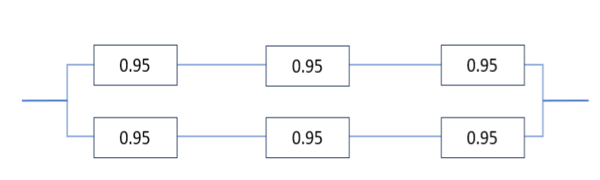

```python
img = Image.open('./Graph2/9-3-a.png')

resized_img = img.resize((600, 180))
display(resized_img)
```

```python
R = 1 - (1-0.95**3)**2

print(f'R = {R:.4f}')
```

```
R = 0.9797
```

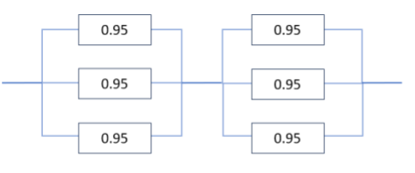

```python
img = Image.open('./Graph2/9-3-b.png')

display(img)
```

```python
R =(1 - (1-0.95)**3)**2

print(f'R = {R:.4f}')
```

```
R = 0.9998
```

### 3. Curva de la bañera (Curva de tasa de fallas)

バスタブ曲線（故障率曲線）

Cuando la tasa de fallas se considera como una función del tiempo t, se le llama función de tasa de fallas, y su representación gráfica se conoce como curva de la bañera (curva de tasa de fallas).

- DFR (Decreasing Failure Rate) 初期故障型
  - Se refiere al periodo en que la tasa de fallos disminuye, siendo una fase donde las contramedidas individuales son efectivas para los fallos que ocurren en las etapas iniciales del desarrollo.
- CFR (Constant Failure Rate) 偶発故障型
  - Se refiere al período en que los fallos se estabilizan, siendo una face en la que las contramedidas ya han sido implementadas y están en un estado de estabilidad.
- IFR (Increasing Failure Rate) 摩耗故障型
  - El periodo en que la tasa de fallos aumenta debido a causas como la fatiga o la degradación.

  [Audio_4](https://drive.google.com/file/d/1yxDwAbb3XVW_mgUS9Rj9sEki1u9axTp2/view?usp=drive_link)

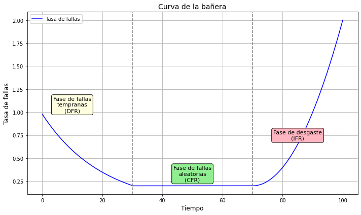

```python
# Eje del tiempo
t = np.linspace(0, 100, 500)

# Tres periodos de la curva de la bañera
# Fase de fallas tempranas (DFR)
dfr = np.exp(-0.05 * t[t < 30]) -0.02

# Fase de fallas aleatorias (CFR)
cfr = np.ones_like(t[(t >= 30) & (t < 70)]) * 0.2

# Fase de desgaste (IFR)
ifr = 0.002 * (t[t >= 70] - 70)**2 + 0.2

# Tasa de fallas (eje y)
failure_rate = np.concatenate([dfr, cfr, ifr])

# Graficar
plt.figure(figsize=(10, 6))
plt.plot(t, failure_rate, label="Tasa de fallas", color='blue')
plt.title("Curva de la bañera", fontsize=14)
plt.xlabel("Tiempo", fontsize=12)
plt.ylabel("Tasa de fallas", fontsize=12)
plt.grid(True)

# Líneas divisorias y etiquetas de fase
plt.axvline(x=30, color='gray', linestyle='--')
plt.axvline(x=70, color='gray', linestyle='--')

plt.text(10, 1.0, 'Fase de fallas\ntempranas\n(DFR)', ha='center', fontsize=11,
         bbox=dict(boxstyle="round", facecolor="lightyellow"))
plt.text(50, 0.25, 'Fase de fallas\naleatorias\n(CFR)', ha='center', fontsize=11,
         bbox=dict(boxstyle="round", facecolor="lightgreen"))
plt.text(85, 0.7, 'Fase de desgaste\n(IFR)', ha='center', fontsize=11,
         bbox=dict(boxstyle="round", facecolor="lightpink"))

plt.legend()
plt.tight_layout()
plt.show()
```

## 09-03 Datos de confiabilidad

信頼性データ

### 1. MTTF, Vida B10

La Vida B10 es una medida que se considera desde la perspectiva de la garantía de valor límite, teniendo en cuenta la dispersión, y muestra el tiempo hasta que falla el 10% del total. En relación con la confiabilidad, el tiempo en el que la confiabilidad alcanza el 90% es la Vida B10.

[Audio_5](https://drive.google.com/file/d/1r-V3HCVZoPs6WNuaetlzM83cNG250XSK/view?usp=drive_link)

## 9.2

５個のアイテムの故障時間が以下で与えられているとき、MTTFの推定値を求めよ。

Dados los siguientes tiempos de falla de 5 items, calcule el valor estimado del MTTF.

Datos： 12,15, 30, 31, 32 （horas）

```python
import numpy as np
import matplotlib.pyplot as plt
from scipy import stats

# Datos de tiempos de falla (en horas)
tiempos_de_falla = np.array([12, 15, 30, 31, 32])

# Cálculo de MTTF (media)
media = np.mean(tiempos_de_falla)

# Tamaño de la muestra y desviación estándar
n = len(tiempos_de_falla)
desv_std = np.std(tiempos_de_falla, ddof=1)  # ddof=1 para muestra

# Intervalo de confianza del 95%
confianza = 0.95
t_crit = stats.t.ppf((1 + confianza) / 2, df=n-1)
margen_error = t_crit * (desv_std / np.sqrt(n))
lim_inf = media - margen_error
lim_sup = media + margen_error

# Mostrar resultados
print(f"MTTF estimado: {media:.2f} horas")
print(f"Intervalo de confianza del 95%: [{lim_inf:.2f}, {lim_sup:.2f}] horas")
```

```
MTTF estimado: 24.00 horas
Intervalo de confianza del 95%: [11.99, 36.01] horas
```

### 2. MTBF MTTR, Disponibilidad

## 9.3

ある一つのシステムにおいて、以下の時間に故障が起こった。ただし、修理にかかる時間は除いてある。この時MTBFの推定値を求めよ。

En un sistema, las fallas ocurrieron en los siguientes tiempos. Sin embargo, el tiempo dedicado a las reparaciones está excluido. Calcule el valor estimado del MTBF en este caso.

Datos：100, 125, 250, 360 （horas）

```python
# Datos
tiempo_total = 360  # tiempo total de operación en horas
numero_fallas = 4   # número de fallas ocurridas

# Cálculo del MTBF
mtbf = tiempo_total / numero_fallas

# Mostrar resultado
print(f"MTBF estimado: {mtbf:.2f} horas")
```

```
MTBF estimado: 90.00 horas
```

#### (2) MTTR (Mean Time to Repair)

El promedio del tiempo de reparación se denomina Tiempo Medio Para Reparar (MTTR) y es una medida correspondiente al MTTF en la durabilidad.

#### (3) Disponibilidad

La disponibilidad es la proporción del tiempo total que representa el tiempo de funcionamiento (uptime), cuando el tiempo total se divide en tiempo de funcionamiento y tiempo de inactividad (tiempo de reparación)

[Audio_6](https://drive.google.com/file/d/11p61aYe6sP5ZBstttEUv-sCghGD591jr/view?usp=drive_link)

## 9.4

MTBF=250（時間）、MTTR=３０（時間）のとき、アベラビリティの推定値を求めよ。

Dado un MTBF de 250 (horas) y MTTR de 30 (horas), calcule el valor estimado de la Disponibilidad.

```python
Availability = 250 /(250+30)

print(f"Disponibilidad estimado: {Availability:.3f}")
```

```
Disponibilidad estimado: 0.893
```

## Por favor, responda a las preguntas del examen de práctica a través del siguiente enlace.

[Simulacro de examen](https://forms.gle/VvLH8vsSjxVFx8EK9)

```python
notebook_name = 'QCKentei2-9.ipynb'
notebook_name_html = notebook_name.replace(".ipynb",".html")

!jupyter nbconvert --to html {notebook_name}
```

```
[NbConvertApp] Converting notebook QCKentei2-9.ipynb to html
[NbConvertApp] Writing 696861 bytes to QCKentei2-9.html
```

```python
from IPython.display import display
from PIL import Image
import gdown
import re

def get_file_id(url,out):
    # 正規表現でファイルIDを抽出
    match = re.search(r'/d/([a-zA-Z0-9_-]+)', url)

    if match:
        file_id = match.group(1)
        print("ファイルID:", file_id)
    else:
        print("ファイルIDが見つかりませんでした。")

    url = f"https://drive.google.com/uc?id={file_id}"

    output = out

    gdown.download(url, output, quiet=False)

    img = Image.open(out)
    display(img)
```

```python
url= 'https://drive.google.com/file/d/10TjgQ9jbrh5iay5qxZT6rYensrgyIY7f/view?usp=drive_link'
out = './Graph2/9-3-a.png'
#get_file_id(url,out)
```

```python
url= 'https://drive.google.com/file/d/1CzDtWb0rH9lI5dfJBk79l2pPFp4a1OBb/view?usp=drive_link'
out = './Graph2/9-3-b.png'
#get_file_id(url,out)
```